# Time Series Homework: Chapter 3 Lesson 4

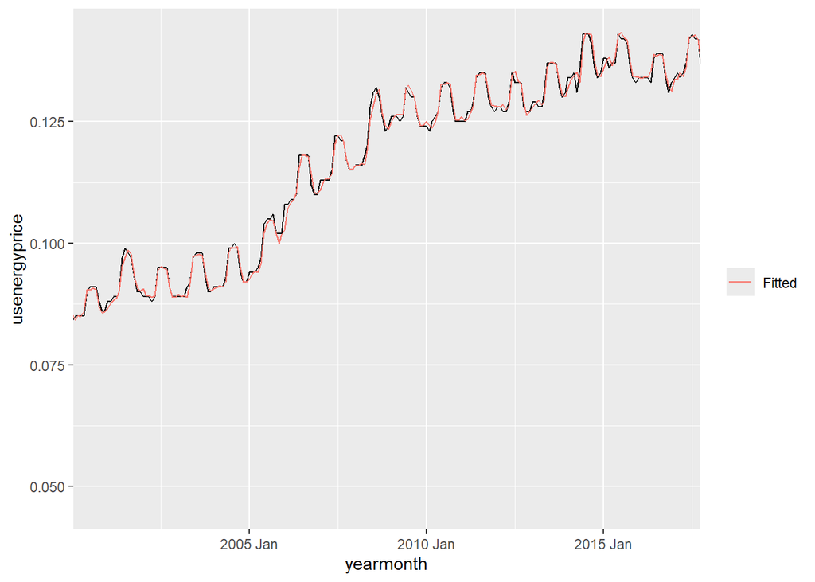

```r
augment(avgkwhr_hw) |>
  ggplot(aes(x = yearmonth, y = usenergyprice)) +
    #coord_cartesian(xlim = yearmonth(c("1978 Nov","1990 Dec"))) +
    coord_cartesian(xlim = yearmonth(c("2000 Nov","2016 Dec"))) +
    geom_line() +
    geom_line(aes(y = .fitted, color = "Fitted")) +
    labs(color = "")
```

```r
avgkwhr_hw <- avgkwhr_tsbl |>
  model(Additive = ETS(usenergyprice ~
        trend("A", alpha = 0.01, beta = 0.0001) +
        error("A") +
        season("A", gamma = 0.02),
        opt_crit = "amse", nmse = 1))
report(avgkwhr_hw)
```

```
Series: usenergyprice
Model: ETS(A,A,A)
  Smoothing parameters:
    alpha = 0.01
    beta  = 1e-04
    gamma = 0.02

  Initial states:
       l[0]         b[0]          s[0]      s[-1]       s[-2]       s[-3]
 0.06314664 0.0001318904 -0.0002283627 0.00315456 0.004239397 0.003979987
       s[-4]        s[-5]       s[-6]        s[-7]        s[-8]        s[-9]
 0.003794928 -0.001439147 -0.00257199 -0.001345245 -0.003035241 -0.002245286
       s[-10]       s[-11]
 -0.001832954 -0.002470646

  sigma^2:  1e-04

      AIC      AICc       BIC
-1708.733 -1707.856 -1649.897
```

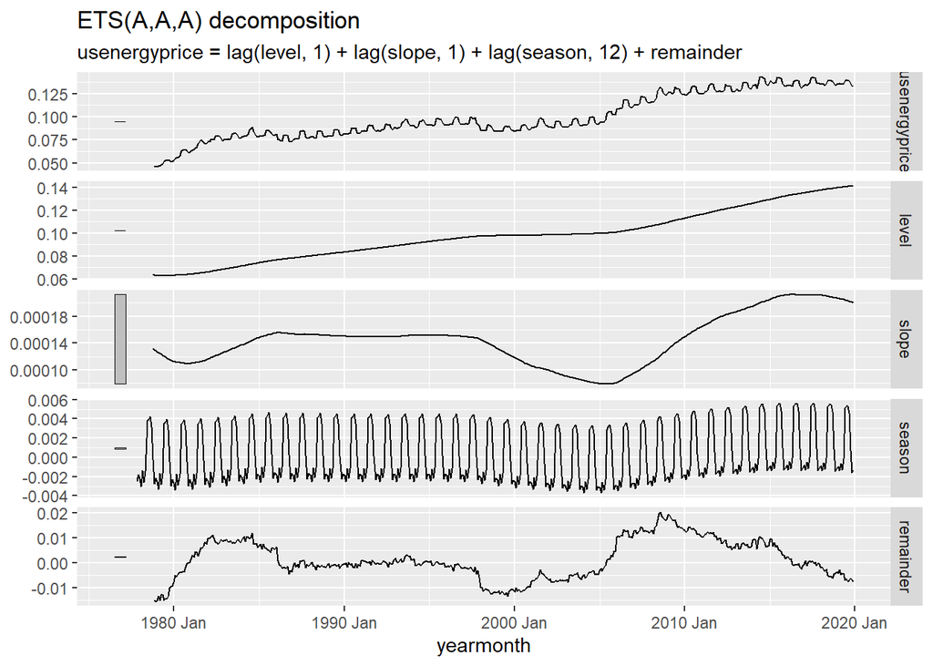

```r
autoplot(components(avgkwhr_hw))
```

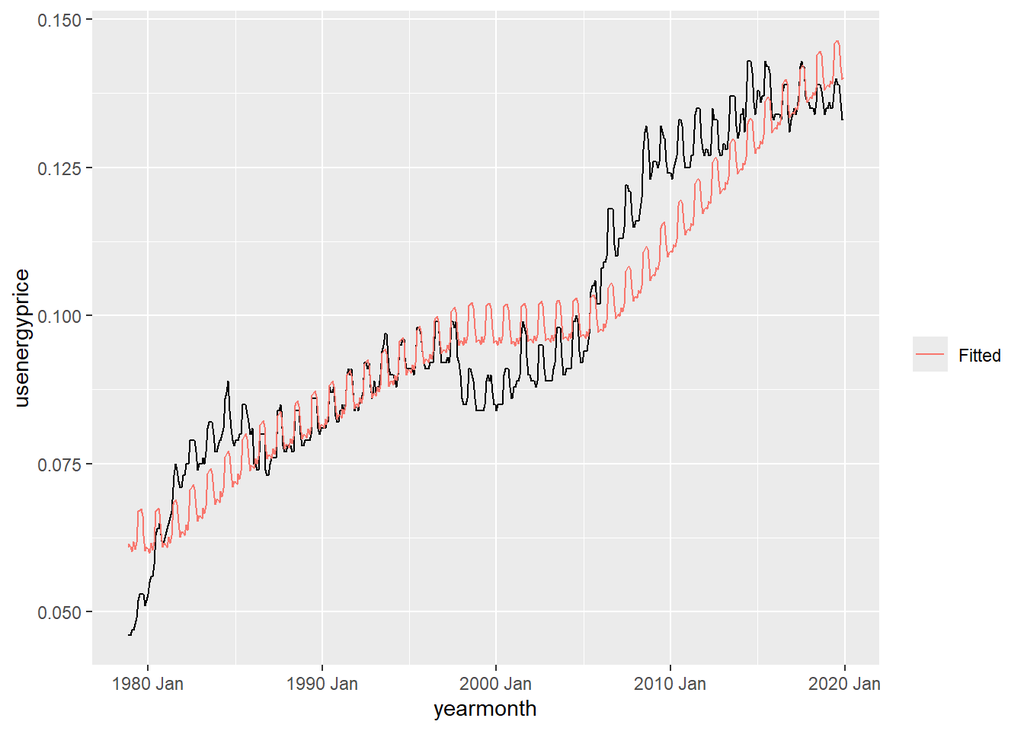

```r
augment(avgkwhr_hw) |>
  ggplot(aes(x = yearmonth, y = usenergyprice)) +
    #coord_cartesian(xlim = yearmonth(c("1978 Nov","1984 Dec"))) +
    #coord_cartesian(xlim = yearmonth(c("2010 Nov","2016 Dec"))) +
    geom_line() +
    geom_line(aes(y = .fitted, color = "Fitted")) +
    labs(color = "")
```

#### b) What parameters values did you choose for $\alpha$, $\beta$, and $\gamma$. Justify your choice.

**Answer**

#### c) Please plot the Holt-Winters forecast of the series for the next 36 months superimposed against the original series. Please see [Figure 7](https://byuistats.github.io/timeseries/chapter_3_lesson_4.html#fig-crime-hw-forecast) in Chapter 3: Lesson 4

**Answer**

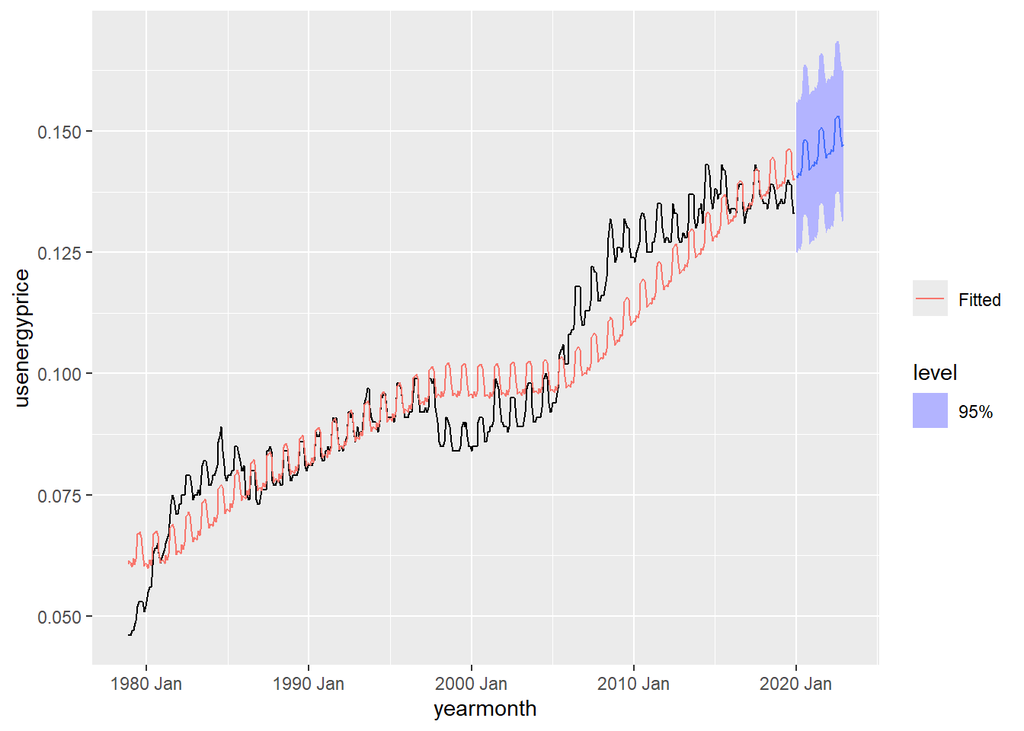

```r
avgkwhr_forecast <- avgkwhr_hw |>
  forecast(h = "3 years")
avgkwhr_forecast |>
  autoplot(avgkwhr_tsbl, level = 95) +
  #coord_cartesian(ylim = c(0,5500)) +
  geom_line(aes(y = .fitted, color = "Fitted"),
    data = augment(avgkwhr_hw)) +
  scale_color_discrete(name = "")
```

#### d) Is the trend in the US Average Price of Electricity series deterministic or stochastic? What is the basis of your evaluation?

**Answer**

Evaluting the series as a whole, it contains more deterministic characteristics than stochastic characteristics.

##### Trend

A loosely constant positive upwards trend is apparent, meaning that overtime the price of electricity is rising. When we examine this with context however it seems strange to say that the cost of electricity itself is rising, in theory it would decrease overtime as we would expect technological advancements to make it easier and more efficient to produce electricity. *However in practice this is somewhat offset by pressure to shift towards renewables which are more expensive*. The trend we observe is more reasonably linked to the economy, when the price of a good rises overtime independent of changes in supply/demand we are observing inflation. So the trend in this series is not actually a result of energy prices themselves but rather the inflation in the economy the prices were collected from.

##### Seasonality

The seasonality appears very constant and deterministic, with an annual period, cycling every 12 months, with high values in the summer (everyone turns on the A/C) and lower values in the winter.

##### Cycles & ‘Random’ Shocks/Events

However stochastic cycles or rather level shocks are observed, ex: 1987, 1998, 2008-2009, & 2014. There’s lots of factors that could be at play here so this is an excellent time to try and harness AI for some help.

Using this prompt and providing a screenshot of the timeseries plot the following *potentially related* context was obtained.

*“I have this data on the average price of energy in the usa from 1980-2020. Im specifically interested in the context and reason that I can observe cycles/level shocks around these time periods: 1987, 1998, 2008-2009, 2014. Can you tell me about world event, political events, policy changes, technological advancements that happened around these timeframes that would be the explanation for these occurrences?”*

**1987**

During the early/mid 1980’s prices were rapidly on the rise, roughly around 1987 we observe a drop and then a slower trend upwards until the next shock in 1998.

*Event:* Black Monday stock market crash (October 19, 1987).

*Context:* The Dow Jones Industrial Average fell by 22.6%, the largest single-day drop in history. Worldwide losses were estimated at US$1.71 trillion.

*Economic Factors:* Concerns over inflation, a weakening dollar, rising oil and commodity prices, protectionism, tensions between the United States and Iran, and the potential end to a long economic expansion contributed to investor jitters.

*Policy/Technological Factors:* Deregulation of wellhead prices for natural gas and the pipeline industry were unleashing market forces, making natural gas and gas-fired power less expensive.

**1998**

Around 1997-1998, we can observe a steep drop in prices follwed by roughly a decade of slowed price growth. World events impacted US policy in favor of spending/investment, most importantly, federal institutions reorganized electrical markets breaking apart the industry and promoting increased competition. This drove prices down in both the short and long-term.

*Event:* Russian Financial Crisis (Ruble Crisis) and Asian Financial Crisis.

*Context:* The Russian government devalued the ruble and defaulted on its debt in August 1998. The Asian Financial Crisis had begun in 1997.

*Economic Factors:* The Russian crisis had severe impacts on neighboring economies and shook investor confidence in global financial markets. International stock markets hit record lows.

*Energy Sector Impact:* Economic downturns in Russia and Asia may have reduced energy demand in those regions, potentially impacting global prices. In the U.S., the Federal Reserve cut interest rates to safeguard the economy against systemic financial crises.

*Policy/Technological Factors:* FERC finalized orders to significantly restructure natural gas markets. Policy makers were also incentivizing alternative technologies, such as wind power.

**2008-2009**

The housing crash and subsequent bank failures lead to a severe resession in the US (and world).

???????????????????????????????????????????????????????????????? WHY DID PRICES RISE? not fall…?

**EDIT** I dug around for like 2 hours yesterday and tried a bunch of different series in FRED. The best thing I was able to find Is that in 2005 the US suffered a few major hurricanes that destroyed a substaintial amount of NG infrastrcutre in the south eastern USA, somewhat connected to this, the prices of NG rose significantly at the end of 2005, however the quickly fell back to more normal levels during 2006/2007 before rising again during the 2008/2009 crisis. 2006 saw a large level rise in electricity expenses *so a 6 month lagged effect from NG prices in 2005?* and then prices also rose during the 2008/2009 crisis. A similar 6 month lagged affect was observed in NG prices rising in Jan 2001 with electric prices rising in Jul 2001. Additionally during 2005, the Energy Policy Act was passed, it was lack luster and disappointing for the NG industry who was hoping for improved feasability for LNG terminal construction (Liquid Nat Gas), which may have lowered outlooks in the industry significantly in a somewhat more long-term effect… I’m far from an expert though.

*Event:* Global Financial Crisis/Great Recession.

*Context:* This was a major worldwide economic crisis that began in 2007 and extended through 2009. The crisis stemmed from predatory lending, a U.S. housing bubble, and excessive risk-taking by financial institutions.

*Economic Factors:* The crisis led to bank failures, plummeting stock and commodity prices, and a global economic slowdown. Unemployment soared.

*Energy Sector Impact:* The recession caused a sharp drop in energy demand and a collapse in oil prices. Financial institutions sank, and the US Government was forced to offer bailouts.

*Policy/Technological Factors:* The American Recovery and Reinvestment Act of 2009 included provisions for investments in renewable energy and energy efficiency, helping to stabilize markets in the early 2010’s.

**2014**

In the early 2010’s we can observe a slow but distinguishable upwards trend, however around 2014 there is a spike and then the upwards trend all but disappears leading up to the present day. This is primarily a result of the US Shale revolution, leading to a large & long term increase in natural gas supply.

Event: Drop in Oil Prices, Geopolitical Tensions in the middle east

Context: Oil prices experienced a significant decline in 2014.

Economic Factors: Several factors contributed to this, including increased U.S. oil production due to fracking. OPEC’s decision not to cut production in response to falling prices exacerbated the oversupply and further contributed to the price decline in late 2014.

Energy Sector Impact: The drop in oil prices affected energy markets globally.

Policy/Technological Factors: The U.S. shale energy revolution increased domestic production. The US lifted its crude export ban in 2015.

### Question 3 - Real US Average Price of Electricity: Additive Holt-Winters Forecasting (25 points)

The upward trend of the series is mostly due to inflation, the generalized increase in prices throughout the economy. One way to quantify inflation is to use a price index, like the Personal Consumption Expenditures Deflator (PCE).The series [HERE](https://fred.stlouisfed.org/series/PCEPILFE) shows that prices in the US have climbed steadily over the last 60 years.Because energy is an important part of the economy, it’s likely that energy prices have followed a similar pattern. Adjusting a series with nominal prices, like the price of electricity, to real prices that account for inflation is simple, divide the original series by the price index. The data set imported below is the real price of electricity, which is the US Average Price of Electricity divided by the PCE index excluding food and energy prices (PCEPILFE). Repeat steps a) to d) for the updated series.

**Answer**

```r
real_avgkwhr <- rio::import("https://byuistats.github.io/timeseries/data/USENERGYPRICE_Real.csv")
```

#### a) Please use the Holt-Winters smoothing method to the series.

**Answer**

```
Plot variable not specified, automatically selected `.vars = realprices`
```

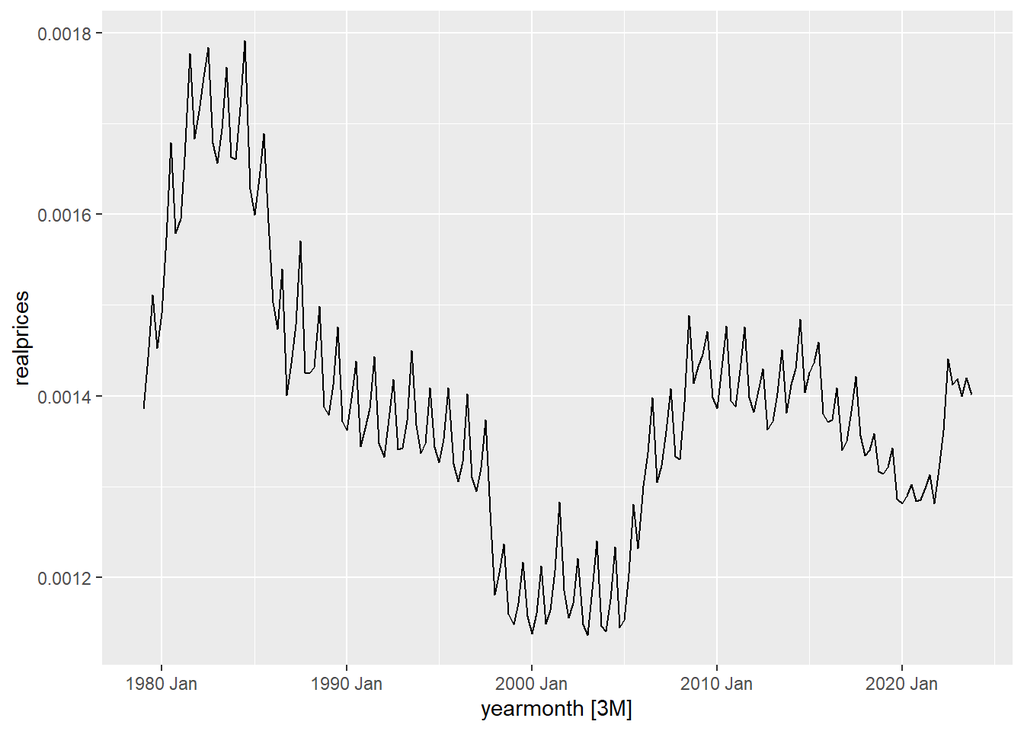

```r
real_avgkwhr$yearmonth <- yearmonth(lubridate::mdy(real_avgkwhr$date))
real_avgkwhr_tsbl <- as_tsibble(real_avgkwhr, index=yearmonth)

autoplot(real_avgkwhr_tsbl)
```

```r
real_avgkwhr_hw <- real_avgkwhr_tsbl |>
  model(Additive = ETS(realprices ~
        trend("A", alpha = 0.3, beta = 0.1) +
        error("A") +
        season("A", gamma = 0.1),
        opt_crit = "amse", nmse = 1))
report(real_avgkwhr_hw)
```

```
Series: realprices
Model: ETS(A,A,A)
  Smoothing parameters:
    alpha = 0.3
    beta  = 0.1
    gamma = 0.1

  Initial states:
        l[0]         b[0]          s[0]        s[-1]        s[-2]         s[-3]
 0.001374842 3.255448e-05 -3.364265e-05 6.889495e-05 1.368712e-06 -3.662101e-05

  sigma^2:  0

      AIC      AICc       BIC
-2770.336 -2769.850 -2751.178
```

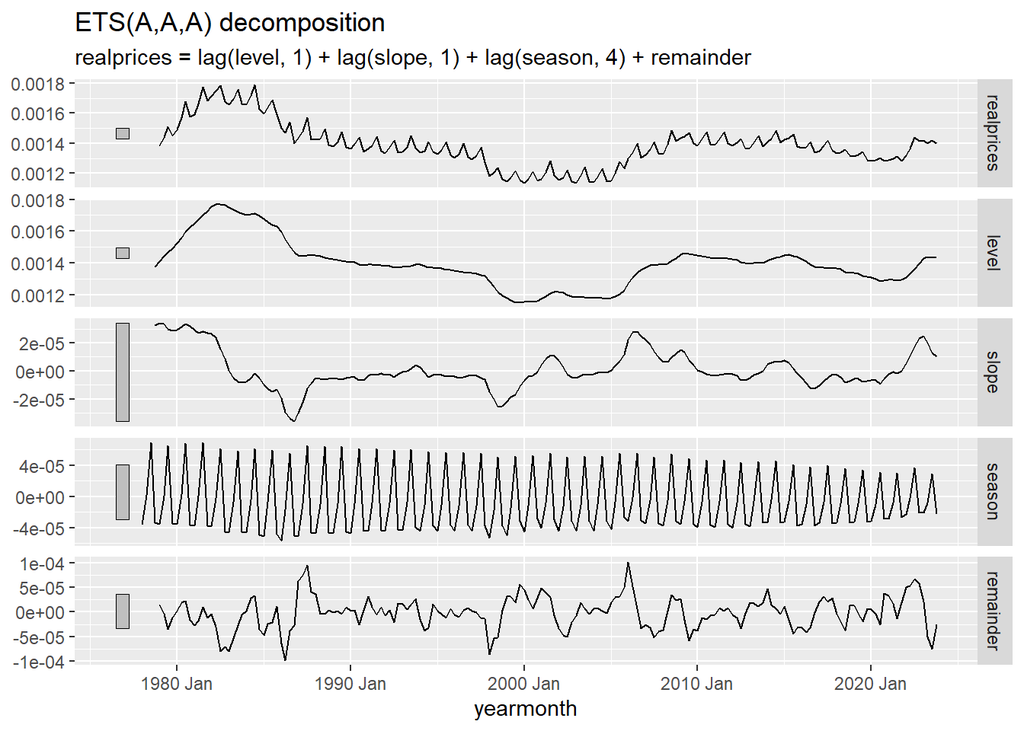

```r
autoplot(components(real_avgkwhr_hw))
```

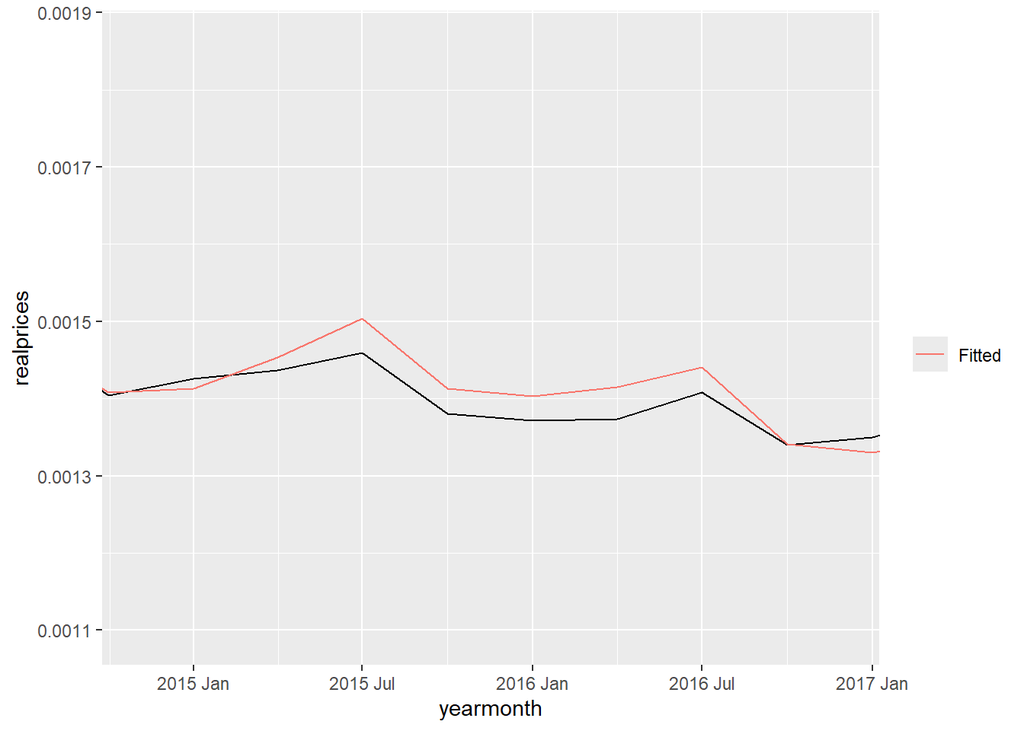

```r
augment(real_avgkwhr_hw) |>
  ggplot(aes(x = yearmonth, y = realprices)) +
    #coord_cartesian(xlim = yearmonth(c("1978 Nov","1990 Dec"))) +
    coord_cartesian(xlim = yearmonth(c("2014 Nov","2016 Dec"))) +
    geom_line() +
    geom_line(aes(y = .fitted, color = "Fitted")) +
    labs(color = "")
```

#### b) What parameters values did you choose for $\alpha$, $\beta$, and $\gamma$. Justify your choice.

**Answer**

In comparison to the original series, the real prices seem to be fluctuating around and average value (roughly $0.0014), additionally the cycles/level shifts around the previously mention periods are now much clearer.

So we can set a Low alpha/beta to ignore the cycles? or high alpha/beta because we want to follow them?

When examining the seasonality of the series somewhere around 2020 there seems to be a significant shift in the pattern

#### c) Please plot the Holt-Winters forecast of the series for the next 12 months superimposed against the original series. Please see [Figure 7](https://byuistats.github.io/timeseries/chapter_3_lesson_3.html#fig-crime-hw-forecast) in Chapter 3: Lesson 3

**Answer**

#### d) Is the trend in the US Average Real Price of Electricity series deterministic or stochastic? What is the basis of your evaluation?

**Answer**

### Rubric

[output not shown]